# Guía 3: Simulaciones y muestreo de la posterior

```r
library(gridExtra)
```

## Ejercicio 1

Simular 10000 datos de una distribución Beta(3,7). Graficar un histograma de los datos y la distribución teórica superpuesta. Dar tres medidas de resumen de la distribución usando los datos simulados.

```r
N <- 10000
simulacion <- data.frame(beta = rbeta(N, 3, 7),
                         gamma = rgamma(N, 4, 2),
                         theta = rnorm(N, 4, 1))
simulacion <- simulacion %>%
  mutate(seq_beta = seq(from= min(beta), to=max(beta), length = N),
         real_beta_density = dbeta(seq_beta, 3, 7),
         seq_gamma = seq(from=min(gamma), to=max(gamma), length = N),
         real_gamma_density = dgamma(seq_gamma, 4 , 2),
         seq_theta = seq(from=min(theta), to=max(theta), length = N),
         real_normal_density = dnorm(seq_theta, 4 , 1),
         )

simulacion %>%
  ggplot()+
  geom_histogram(aes(x=beta, y=..density..), fill = "blue", alpha = 0.5) +
  geom_line(aes(x = seq_beta, y=real_beta_density))

simulacion %>%
  ggplot()+
  geom_histogram(aes(x=gamma, y=..density..), fill = "green", alpha = 0.5) +
  geom_line(aes(x = seq_gamma, y=real_gamma_density))

simulacion %>%
  ggplot()+
  geom_histogram(aes(x=theta, y=..density..), fill = "red", alpha = 0.5) +
  geom_line(aes(x = seq_theta, y=real_normal_density))
```

[output not shown]

```r
summary(simulacion$beta)
summary(simulacion$gamma)
summary(simulacion$theta)
```

[output not shown]

## Ejercicio 3

Supongamos que tomaron datos $y$ y con un modelo bayesiano llegaron a que la distribución posterior para la probabilidad de que respondan un mail dentro de las 24 horas $\theta$, , es Beta(2,5). Les llega un nuevo mail. ¿Cuál es la probabilidad de que lo respondan en menos de 24 horas? Es decir, se pide $P(\tilde{y}=1 | y)$, la posterior predictive. Resolverlo de dos formas:

```r
N <- 10000
simulacion <- data.frame(theta = rbeta(N, 2, 5)) %>%
  mutate(y = rbinom(N, 1, theta))


simulacion %>%
  group_by(y) %>%
  summarise(n = n()) %>%
  mutate(freq = n / sum(n))
```

[output not shown]

## Ejercicio 4

Supongamos que quieren saber si los mails que reciben los lunes los responden más rápido que los que reciben los sábados. Con datos que recolectan de su propia experiencia llegan a que la distribución posterior para $\theta_L$ es Beta(3,7) (correspondiente a mails que llegan los lunes) y $\theta_S$ es Beta(4,8) para los que llegan los sábados. Para responder la pregunta simulando, sigan estos pasos:

1. Simular 10000 valores de $\theta_L$ y $\theta_S$.
2. Calcular, para cada para de valores $\theta_L(i)$ y $\theta_S(i)$, la diferencia $\delta_i = \theta_L(i)-\theta_S(i)$.
3. Usar las muestras aleatorias $\delta_i$ para responder la preguta. Ej: preguntarse por la probabilidad de que esa diferencia sea positiva.

```r
N <- 10000
simulacion <- data.frame(theta_L = rbeta(N, 3, 7),
                         theta_S = rbeta(N, 4, 8)) %>%
  mutate(delta = theta_L - theta_S,
         positivo = delta > 0)

#simulacion %>%
#  summarise(num_true = sum(positivo == TRUE), num_false = sum( positivo== FALSE))
simulacion %>%
  group_by(positivo) %>%
  summarise(n = n()) %>%
  mutate(freq = n / sum(n))
```

[output not shown]

Los mails que reciben los lunes no los responden más rápido que los que reciben los sábados.

## Ejercicio 5

Un jardín botánico tiene tres especies de árboles, A, B y C. El 18% del total de los árboles está infectado con un plaga. Entre los infectados, 15% son A, 80% son B y 5% son C. Entre los no infectados 20% son A, 10% son B y 70% son C. Para monitorear el avance de la plaga, un empleado se acerca a un árbol cualquiera para examinarlo. Para resolver este ejercicio, simular datos de 10000 árboles.

```r
N <- 10000
especies <- c('A', 'B', 'C')
simulacion_arboles <- data.frame(infectado = rbinom(N, 1, 0.18))
simulacion_arboles <- simulacion_arboles %>%
  mutate(especie = case_when(
    infectado == 1 ~ sample(especies, n(), prob = c(0.15, 0.80, 0.05), replace=T),
    infectado == 0 ~ sample(especies, n(), prob = c(0.20, 0.10, 0.70), replace= T)
  ))
```

1. Cuál es la probabilidad de que el árbol esté infectado (prior)?

```r
simulacion_arboles %>%
  group_by(infectado) %>%
  summarise(n=n()) %>%
  mutate(freq = n / sum(n))
```

| infectado | n | freq |
| --- | --- | --- |
| 0 | 8235 | 0.8235 |
| 1 | 1765 | 0.1765 |

2. Si resulta que el árbol seleccionado es de la especie B. ¿Qué probabilidad tenía de haber seleccionado uno de esa especie?

```r
simulacion_arboles %>%
  group_by(especie) %>%
  summarise(n=n()) %>%
  mutate(freq = n / sum(n))
```

| especie | n | freq |
| --- | --- | --- |
| A | 1930 | 0.193 |
| B | 2170 | 0.217 |
| C | 5900 | 0.590 |

3. Cuál es la probabilidad posterior de que el árbol seleccionado, de la especie B, esté infectado?

```r
simulacion_arboles %>%
  filter(especie=='B') %>%
  group_by(infectado) %>%
  summarise(n=n()) %>%
  mutate(freq = n / sum(n))
```

| infectado | n | freq |
| --- | --- | --- |
| 0 | 767 | 0.3534562 |
| 1 | 1403 | 0.6465438 |

4. Comparar la probabilidad a priori de que el árbol esté infectado con la probabilidad posterior (luego de saber que el árbol seleccionado es de la especie B)?
5. Comparar los resultados de las simulaciones con el resultado exacto usando la regla de Bayes.

## Ejercicio 6

```r
one_mh_iteration_ej6 <- function(current, sigma, datos=NA){
    proposed <- rnorm(1, current, sigma)
    proposal_plaus <- dnorm(proposed, 4, 0.6)
    current_plaus <- dnorm(current, 4, 0.6)
    acceptance_prob <- min(1, proposal_plaus/current_plaus)
    return(data.frame(current, proposed, acceptance_prob))
}

metropolis_hasting <- function(N, theta_0, sigma, one_mh_iteration, datos=NA){
  theta <- rep(0, N)
  theta[1] <- theta_0
  for (i in 1:(N-1)) {
    current_theta <- theta[i]
    simulation <- one_mh_iteration(current_theta, sigma, datos)
    proposed_theta <- simulation$proposed
    acceptance_prob <- simulation$acceptance_prob
    next_theta <- sample(c(proposed_theta, current_theta),
                         size=1,
                         prob=c(acceptance_prob, 1-acceptance_prob))
    theta[i+1] <- next_theta
  }
  return(data.frame(iteration = c(1:N), theta))
}

mh_simulation_1 <- metropolis_hasting(10000, 0, 2, one_mh_iteration_ej6)
```

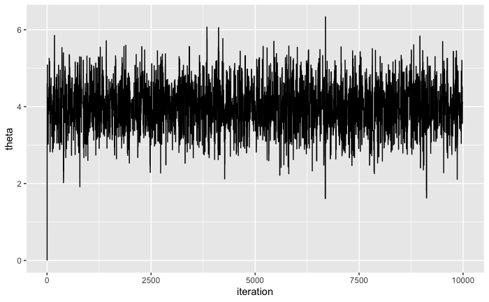

```r
mh_simulation_1 %>%
  ggplot(aes(x=iteration, y = theta)) +
  geom_line()
```

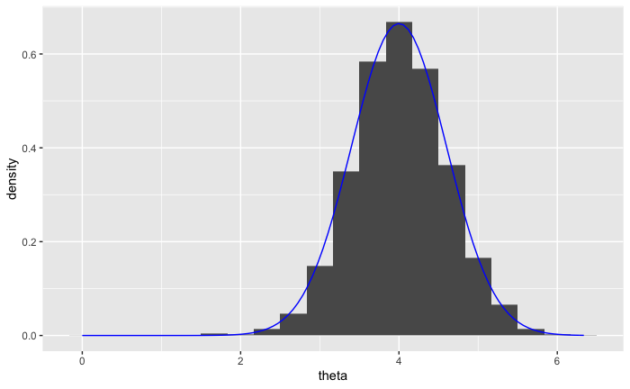

```r
mh_simulation_1 %>%
  ggplot(aes(x=theta)) +
  geom_histogram(aes(y=..density..), bins= 20) +
  stat_function(fun=dnorm, args = list(4, 0.6), color="blue")
```

## Ejercicio 7

Ientificar una pregunta que se pueda responder con un modelo Beta-Binomial para la probabilidad $\theta$ de que ocurra algo. Por ejemplo: proporción de colectivos que vienen llenos cuando vienen a Exactas, etc.

1. Proponer un prior para $\theta$.

Tomo prior uniforme. $\pi\sim\beta(1,1)$

2. Juntar datos (de verdad o inventados).

```r
datos_bus <- rbinom(100, 1, 0.2)
n <- length(datos_bus)
y <- sum(datos_bus)
```

3. Simular 2000 valores de $\theta$ obtenidos con el algoritmo de Metropolis-Hastings.
4. Graficar la cadena resultante (secuencia de muestras). ¿Están satisfechos con el resultado? ¿A qué hay que estar atentos para aceptar las muestras?

```r
# asumo que la proporción real de colectivos que vienen llenos es theta=0.2
# tomamos como prior una beta(1,1), uniforme(0,1)

one_mh_iteration_ej7 <- function(current, sigma, datos){
    proposed <- rbeta(1, 1, 1)
    y <- sum(datos)
    n <- length(datos)
    proposal_plaus <- dbeta(proposed, 1, 1) * dbinom(y, n, proposed)
    current_plaus <- dbeta(current, 1, 1) * dbinom(y, n, current)
    acceptance_prob <- min(1, proposal_plaus/current_plaus)
    return(data.frame(current, proposed, acceptance_prob))
}
mh_bus <- metropolis_hasting(N=2000, sigma=1, theta_0 = 0.5, one_mh_iteration = one_mh_iteration_ej7, datos=datos_bus)
```

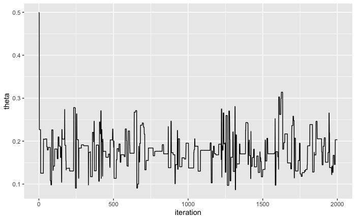

```r
mh_bus %>%
  ggplot(aes(x=iteration, y = theta)) +
  geom_line()
```

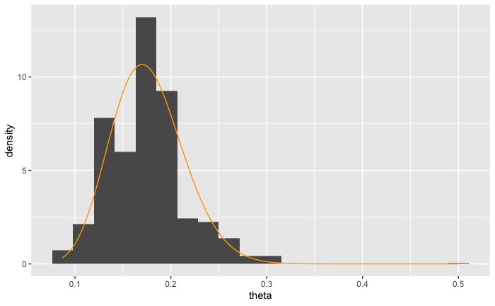

```r
mh_bus %>%
  ggplot(aes(x=theta)) +
  geom_histogram(aes(y=..density..), bins= 20) +
  stat_function(fun=dbeta, args = list(1+y, 1+n-y), color="orange")
```

## Ejercicio 8

Identificar una pregunta que se pueda responder con un modelo Normal para $\mu$, un valor medio de interés. Por ejemplo: la temperatura máxima promedio en Otoño en Buenos Aires, el tiempo medio de uso de celular diario, etc.

1. Proponer un prior para $\mu$.

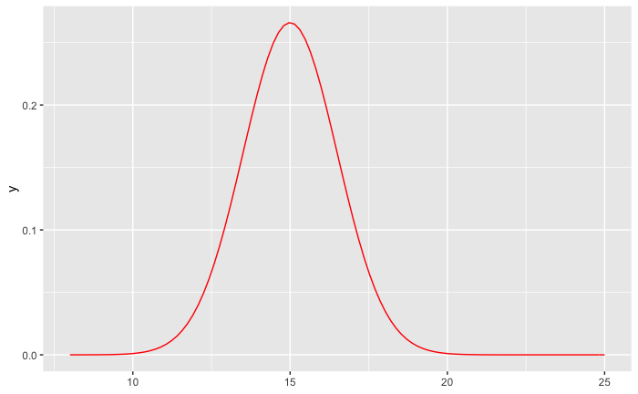

```r
ggplot() +
  xlim(8,25) +
  stat_function(fun=dnorm, args = list(15, 1.5), color="red")
```

2. Juntar datos (de verdad o inventados).

Simulo 100 datos. Para ello, asumo que en realidad el valor medio es $\mu\sim\mathcal{N}(18,1)$

```r
datos_temp <- rnorm(100, 18, 1)
```

3. Simular 2000 valores de $\mu$ obtenidos con el algoritmo de Metropolis-Hastings. Usar $\sigma$ fijo.

```r
one_mh_iteration_ej8 <- function(current, sigma, datos){
    proposed <- rnorm(1, current, sigma)
    # prior normal(15, 1.5) * likelihood(datos, mu, 1), asumo que conozco sigma de los datos
    proposal_plaus <- dnorm(proposed, 15, 1.5) * prod(dnorm(datos, proposed, 1))
    current_plaus <- dnorm(current, 15, 1.5) * prod(dnorm(datos, current, 1))
    acceptance_prob <- min(1, proposal_plaus/current_plaus)
    return(data.frame(current, proposed, acceptance_prob))
}
mh_temperatura <- metropolis_hasting(N=2000, theta_0=0.5, sigma=1, one_mh_iteration = one_mh_iteration_ej8, datos_temp)
```

4. Graficar la cadena resultante (secuencia de muestras). ¿Están satisfechos con el resultado? ¿A qué hay que estar atentos para aceptar las muestras?

[figure not shown]

```r
mh_temperatura %>%
  ggplot(aes(x=iteration, y = theta)) +
  geom_line()
```

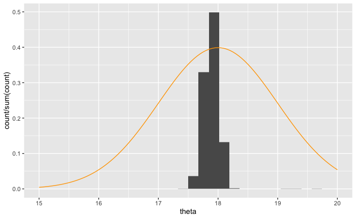

```r
mh_temperatura %>%
  ggplot(aes(x=theta)) +
  geom_histogram(aes(y=..count../sum(..count..)), bins= 30) +
  stat_function(fun=dnorm, args = list(18, 1), color="orange") +
  xlim(15,20)
```

```r
  # stat_function(fun=dnorm, args = list(15, 1.5), color='grey')
```